# Maps with R

Ilya Kashnitsky

17 July 2020

# Map projections

[interactive chart not shown]

https://xkcd.com/977/

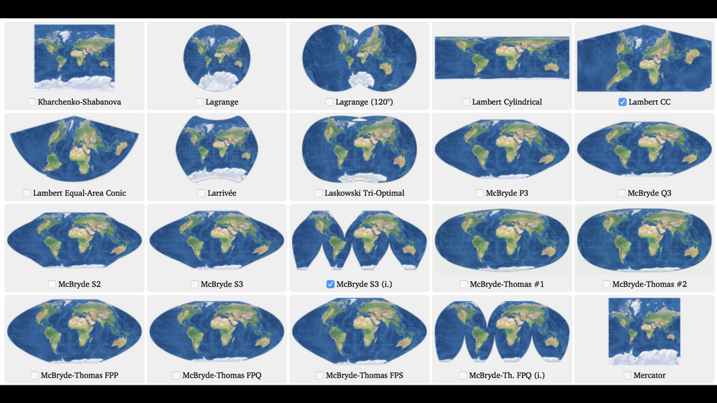

## Mercator explained

[video not shown]

## Mercator size

> Animating the Mercator projection to the true size of each country in relation to all the others.  
> Now with added Antarctica![#dataviz](https://twitter.com/hashtag/dataviz?src=hash&ref_src=twsrc%5Etfw) [#maps](https://twitter.com/hashtag/maps?src=hash&ref_src=twsrc%5Etfw) [#GIS](https://twitter.com/hashtag/GIS?src=hash&ref_src=twsrc%5Etfw) [#projectionmapping](https://twitter.com/hashtag/projectionmapping?src=hash&ref_src=twsrc%5Etfw) [#mapping](https://twitter.com/hashtag/mapping?src=hash&ref_src=twsrc%5Etfw) [pic.twitter.com/VNDRSjOpXe](https://t.co/VNDRSjOpXe)

> — Neil Kaye (@neilrkaye) [January 8, 2019](https://twitter.com/neilrkaye/status/1082660077625061384?ref_src=twsrc%5Etfw)

## Mercator: Greenland vs Africa

> We live by the [#Mercator](https://twitter.com/hashtag/Mercator?src=hash&ref_src=twsrc%5Etfw) projection of the world. Check yourself the true size of your country 🌍  
> For example, Greenland and Africa are shown in Mercator projection as roughly the same size, although in reality Africa is about fourteen times larger!  
> By [@neilrkaye](https://twitter.com/neilrkaye?ref_src=twsrc%5Etfw) [pic.twitter.com/km1tJO80qX](https://t.co/km1tJO80qX)

> — Zbigniew PISARSKI (@Pisarski) [October 17, 2018](https://twitter.com/Pisarski/status/1052486032766197760?ref_src=twsrc%5Etfw)

## New fancy projection (Waterman Butterfly)

[video not shown]

> behold, my greatest invention: the Mercator Globe [pic.twitter.com/AcY0XqBMCp](https://t.co/AcY0XqBMCp)

> — 𝑨𝒔𝒉⬩ (@ashastral) [December 11, 2018](https://twitter.com/ashastral/status/1072313190590103557?ref_src=twsrc%5Etfw)

> My first real [@observablehq](https://twitter.com/observablehq?ref_src=twsrc%5Etfw) notebook: Swiss Grid vs. Web Mercatorhttps://t.co/gVH5aD8qET [pic.twitter.com/tzS6ZqwYdB](https://t.co/tzS6ZqwYdB)

> — Roman Karavia (@rkaravia) [April 4, 2019](https://twitter.com/rkaravia/status/1113832390760239104?ref_src=twsrc%5Etfw)

[interactive chart not shown]

http://epsg.io

# Are we too focused on areas?

> As many of you noticed the map I used is not using the proper vote results from the 2016 U.S. presidential election. I have been mislead by the map posted by Lara Trump which shows more red than it should be. Here is an updated version of the GIF: [pic.twitter.com/et2P9qn5P3](https://t.co/et2P9qn5P3)

> — Karim Douïeb (@karim_douieb) [October 9, 2019](https://twitter.com/karim_douieb/status/1181934417650040832?ref_src=twsrc%5Etfw)

> Stärkste Partei pro Gemeinde, Nationalratswahl 2019.  
> Stärkste Partei pro Gemeinde, skaliert nach Einwohnerzahl.  
> Daten: [@StatSchweiz](https://twitter.com/StatSchweiz?ref_src=twsrc%5Etfw). Code: [@rkaravia](https://twitter.com/rkaravia?ref_src=twsrc%5Etfw). [pic.twitter.com/oecFJblkzP](https://t.co/oecFJblkzP)

> — NZZ Visuals (@nzzvisuals) [October 21, 2019](https://twitter.com/nzzvisuals/status/1186225049960943617?ref_src=twsrc%5Etfw)

# Sources of geodata

[interactive chart not shown]

https://gadm.org/data.html

[interactive chart not shown]

http://wiki.openstreetmap.org/wiki/Shapefiles

## google “download shapefile” =)

# Where to go next?

## Materials

[interactive chart not shown]

https://geocompr.robinlovelace.net

[interactive chart not shown]

https://cengel.github.io/R-spatial/

[interactive chart not shown]

https://bookdown.org

[interactive chart not shown]

https://www.r-bloggers.com

# Packages to explore

[interactive chart not shown]

https://cran.r-project.org/web/packages/tmap/vignettes/tmap-getstarted.html

[interactive chart not shown]

https://r-spatial.github.io/sf

[interactive chart not shown]

https://walkerke.github.io/tidycensus/articles/basic-usage.html

[interactive chart not shown]

https://bhaskarvk.github.io/tilegramsR/

[interactive chart not shown]

https://cran.r-project.org/web/packages/voteogram/vignettes/intro_to_voteogram.html

[interactive chart not shown]

https://www.r-graph-gallery.com/cartogram.html

[interactive chart not shown]

https://xinye1.github.io/projects/brexit-cartogram-leaflet/